# Final Project

# Project Introduction

## **Motivating Questions and Scope on Analysis**

The NBA is the largest basketball league on the planet and one of the most popular sports to watch in America. Every year in the NBA, players change to new teams, franchises get better, some get worse, and a new champion is crowned. The unpredictability of the NBA is what makes it so captivating to the viewers but what if there was order behind all of the chaos. In this project, we will seek to answer the motivating question: To what extent does team context influence teams performance.

## **Background Information**

**NBA:** The National Basketball Association, NBA, is the biggest and premier basketball league in the world. It is made up of currently active 30 teams, which come from all over North America. The NBA was founded in 1949 when the two previous basketball leagues in North America, the Basketball Association of America (BAA) and the National Basketball League (NBL) were merged into one. The league is structured in two conferences the Eastern Conference and the Western Conference, with 15 teams in each. The conferences are further divided into 3 divisions with 5 teams each. Each season stretches from October to April and includes 82 games. After the regular season is done there is a Playoff where the best 16 teams, 8 teams from each conference, compete in a tournament to determine the NBA champion. Before the playoffs there is also a postseason competition called Play-In Tournament. The Play-In Tournament is to determine the final two playoff teams in each conference. Teams that finish 7th through 10th in the regular-season standings compete for the last two playoff spots. Our dataset stretches all the way back to 1947 but for the scope of this project we have decided to look at the games from 2015 to present day. This decision was made because it both removes any nonactive teams and limits our research to only the modern NBA.

**Research**: As previously mentioned, the NBA is unpredictable. While some teams stay consistent season to season, there are many factors that can influence a team’s performance. A team can change coach, move facilities, get a bad traveling and game schedule or a star player can move teams. Because of this unpredictability of the NBA, we set out to investigate 3 different topics. We wanted to use NBA data to investigate travel fatigue, the influence of home court advantage, and the association between team context (coaching, facilities and team fit) and game outcomes. Our dataset for this project contains detailed information on individual NBA games, including team identities, scores, location, and performance-related indicators. To supplement this we have also compiled a table of the team home arena locations and used their coordinates to determine the travel distance.

## **Variable Explanation**

1. **home** (numeric), this variable gives either a home or away designation for each game mentioned in the data set. The variable is saved as a one if the game was played at home or a 0 if the game was played away.
2. **gameDate** (numeric) This gives us the exact data and time that a specific game was played between two teams. This variable will be used to divide matches into certain seasons helping us distinguish how a team performed in a season.
3. **year** (numeric) The year each game was played. This was derived from the gameDate variable using the lubridate data set. It will be used to divide matches into certain seasons helping us distinguish how a team performed in a season.
4. **teamName** (character) This grants us the name of each team that played in a specific match. This is used throughout the whole project to attribute stats and measurements to a specific team.
5. **teamId** (numeric) this gives a unique 10 digit id number to each franchise that appeared in the data set. Team ID was used to filter out certain foreign teams that were mentioned in the data set only once.
6. **plusMinusPoints** (numeric) Plus minus points is another variable measured in the data set. as the difference in points scored between teams in a game, an important measure because it captures not just who won, but how decisively they won. This will give us a measure of how a team performed both offensively and defensively throughout a game.
7. **minutes played** (per player per game) Minutes a player played in a given game. Used to calculate points per minute and to weight averages for players that played lots of minutes
8. **points** (numeric) (per player per game) points a player scored in a game. Used to calculate the mean, standard deviation and the z_score of a player’s points in any given game.
9. **Field Goals Attempts** (numeric) (per player per game) shots taken in a game with intent to score. Used to calculate the mean, standard deviation and the z_score of a player’s field goal attempts in any given game.
10. **Field Goal Percentage** (numeric) (per player per game) the fraction of shots made over the shots taken of a player in a given game. Used to calculate the mean, standard deviation and the z_score of a player’s field goal percentage in any given game.
11. **personId** - a unique identifier per player. Used when we need to group by players.
12. **playerteamCity** (per player per game). The City that a team plays for. Since 2015 is a 1 to 1 mapping i.e. there is a unique city for each team and a unique team for each city. Thus, is also used in some grouping functions, however mainly used for calculating distance with the lookup table.
13. **win** (numeric). The team that won that game is given a value of 1 and the team that lost is given a value of 0.
14. **gameType** (character) The type of game. Regular Season, Playoffs, specialty games etc. Used to filter out specialty games.

Each variable in our study plays a specific role in understanding game outcomes. Home-court advantage is represented in the dataset through the home/away field, which identifies where the game occurred. This allows us to compare home win rates and quantify whether teams perform differently when supported by their home crowd.

**Calculated Variable Explanation**

1. **PM_mean** (numeric): This gives the mean plus minus points of a team over all their games over a year.
2. **PM_home** (numeric): This gives the mean plus minus points for only home games of a team over all their games over a year.
3. **PM_away** (numeric): This gives the mean plus minus points for only away games of a team over all their games over a year.
4. **Difference** (numeric): The difference variable gives us the difference between a teams PM_mean and the PM_home/away variable for each year.
5. **home_final** (numeric): The home final gives the mean difference in plus minus for a team throughout the last 10 years. There is one value for every franchise.
6. **away_final** (numeric): The away final gives the mean difference in plus minus for a team throughout the last 10 years. There is one value for every franchise.
7. **total_wins** (numeric): The total amount of wins accumulated by one team.
8. **total_games** (numeric): The total amount of games played by one team.
9. **winRate** (numeric): The percentage of games a team won.
10. **avgAssoc**
    $$stat$$
    (numeric):
    $$stat$$
    is one of field goal attempts per game (FAPG), points per game (PPG), points per minute (PPM), or field Goal % (FGP).
    avgAssoc is an index of the teams association with increasing or decreasing play performance measured by
    $$stat$$
11. $$stat$$
    Effect (numeric):
    $$stat$$
    is one of above.
    The estimated effect of avgAssoc
    $$stat$$
    but in the units of
    $$stat$$

# **Home Court Advantage Section**

First thing that we need to do is load in the data and upload the libraries we will be using.

I selected the columns that I am going to use throughout this section and filtered out some foreign teams that are not relevant in this context. We also filtered for the last 10 years (Since 2015) just to make sure we have data on the most recent era of the NBA.

```r
library(tidyverse)
library(lubridate)
Team_Data <- read_csv("data/TeamStatistics.csv")
new_data <- Team_Data %>%   mutate(year = year(gameDate)) %>%
  select( gameDate, year, teamName, teamId, home, plusMinusPoints) %>%
  # Selecting the columns from the dataset that are useful to us

  filter(!(teamId %in% c(15016,15018, 50013, 50014))) %>%
  filter(year(gameDate) >= 2015)
new_data
```

```
## # A tibble: 29,244 × 6
##    gameDate             year teamName      teamId  home plusMinusPoints
##    <dttm>              <dbl> <chr>          <dbl> <dbl>           <dbl>
##  1 2025-11-08 22:30:00  2025 Clippers  1610612746     1             -11
##  2 2025-11-08 22:30:00  2025 Suns      1610612756     0              11
##  3 2025-11-08 21:00:00  2025 Nuggets   1610612743     1              17
##  4 2025-11-08 21:00:00  2025 Pacers    1610612754     0             -17
##  5 2025-11-08 20:00:00  2025 Hawks     1610612737     1              20
##  6 2025-11-08 20:00:00  2025 Cavaliers 1610612739     1               6
##  7 2025-11-08 20:00:00  2025 Pelicans  1610612740     0              -7
##  8 2025-11-08 20:00:00  2025 Bulls     1610612741     0              -6
##  9 2025-11-08 20:00:00  2025 Lakers    1610612747     0             -20
## 10 2025-11-08 20:00:00  2025 Heat      1610612748     1               5
## # ℹ 29,234 more rows
```

```r
#some more filtering to remove unwanted foriegn teams and get the years that I want
```

Now we want to create 3 new tables. Each table is going to have an entry for a team, one for every year since 2015. There will be one table with the mean plus minus points for every game the team played through the year, one for average plus minus for only away games. and one for only home games.

```r
#Getting new tables here with the away, home, and all time plus minuses for every franchise and year

mean_PM <- new_data %>%
  group_by(teamName,year)  %>%
  summarise(PM_mean = mean(plusMinusPoints, na.rm = TRUE))
mean_PM
```

```
## # A tibble: 330 × 3
## # Groups:   teamName [30]
##    teamName  year PM_mean
##    <chr>    <dbl>   <dbl>
##  1 76ers     2015  -8.66
##  2 76ers     2016  -8.63
##  3 76ers     2017  -2.52
##  4 76ers     2018   5.29
##  5 76ers     2019   3.92
##  6 76ers     2020   0.490
##  7 76ers     2021   4.18
##  8 76ers     2022   3.93
##  9 76ers     2023   5.65
## 10 76ers     2024  -2.20
## # ℹ 320 more rows
```

```r
home_PM <- new_data %>%
  filter(home == 1) %>%
  group_by(teamName,year)  %>%
  summarise(PM_home = mean(plusMinusPoints, na.rm = TRUE))
home_PM
```

```
## # A tibble: 330 × 3
## # Groups:   teamName [30]
##    teamName  year PM_home
##    <chr>    <dbl>   <dbl>
##  1 76ers     2015  -5.84
##  2 76ers     2016  -6.88
##  3 76ers     2017   0.225
##  4 76ers     2018  10.4
##  5 76ers     2019   8.31
##  6 76ers     2020   6.33
##  7 76ers     2021   7.36
##  8 76ers     2022   5.43
##  9 76ers     2023   6.62
## 10 76ers     2024  -1.5
## # ℹ 320 more rows
```

```r
away_PM <- new_data %>%
  filter(home == 0) %>%
  group_by(teamName,year)  %>%
  summarise(PM_away = mean(plusMinusPoints, na.rm = TRUE))
away_PM
```

```
## # A tibble: 330 × 3
## # Groups:   teamName [30]
##    teamName  year PM_away
##    <chr>    <dbl>   <dbl>
##  1 76ers     2015 -11.1
##  2 76ers     2016 -11
##  3 76ers     2017  -4.72
##  4 76ers     2018  -0.444
##  5 76ers     2019  -0.388
##  6 76ers     2020  -4.70
##  7 76ers     2021   1.26
##  8 76ers     2022   2.09
##  9 76ers     2023   4.76
## 10 76ers     2024  -2.83
## # ℹ 320 more rows
```

In this section I am joining the 3 new tables together. This is an important step because it allows be to run calculations on each of my newly calculated variables. It is very difficult to do calculations with data from different data frames, so joining them fixed this issue.

```r
#joining all these new tables together into one

All_PM <- mean_PM %>%
  left_join(home_PM, by = join_by(teamName, year)) %>%
  left_join(away_PM, by = join_by(teamName, year))
All_PM
```

```
## # A tibble: 330 × 5
## # Groups:   teamName [30]
##    teamName  year PM_mean PM_home PM_away
##    <chr>    <dbl>   <dbl>   <dbl>   <dbl>
##  1 76ers     2015  -8.66   -5.84  -11.1
##  2 76ers     2016  -8.63   -6.88  -11
##  3 76ers     2017  -2.52    0.225  -4.72
##  4 76ers     2018   5.29   10.4    -0.444
##  5 76ers     2019   3.92    8.31   -0.388
##  6 76ers     2020   0.490   6.33   -4.70
##  7 76ers     2021   4.18    7.36    1.26
##  8 76ers     2022   3.93    5.43    2.09
##  9 76ers     2023   5.65    6.62    4.76
## 10 76ers     2024  -2.20   -1.5    -2.83
## # ℹ 320 more rows
```

Now to calculate how each teams home stadium affects their performance, we used a nowise function to subtract a teams Plus minus for all their home games by their total mean plus minus for every year. This difference was saved in the variable “Difference”. Then the same exact thing was done for their away games.

After we get these values for each team for every year. We then grouped these new tables by team and found the average for each team throughout all of the years. In return we are left with a score for each team that tells us how much better/worse a team plays at home compared to their average performance.

```r
diff_home <- All_PM %>%
  group_by(teamName, year) %>%
  summarise(Difference = PM_home - PM_mean)
diff_home
```

```
## # A tibble: 330 × 3
## # Groups:   teamName [30]
##    teamName  year Difference
##    <chr>    <dbl>      <dbl>
##  1 76ers     2015      2.83
##  2 76ers     2016      1.75
##  3 76ers     2017      2.75
##  4 76ers     2018      5.06
##  5 76ers     2019      4.39
##  6 76ers     2020      5.84
##  7 76ers     2021      3.18
##  8 76ers     2022      1.50
##  9 76ers     2023      0.973
## 10 76ers     2024      0.696
## # ℹ 320 more rows
```

```r
diff_away <- All_PM %>%
  group_by(teamName, year) %>%
  summarise(Difference = PM_away - PM_mean)
diff_away
```

```
## # A tibble: 330 × 3
## # Groups:   teamName [30]
##    teamName  year Difference
##    <chr>    <dbl>      <dbl>
##  1 76ers     2015     -2.48
##  2 76ers     2016     -2.37
##  3 76ers     2017     -2.20
##  4 76ers     2018     -5.74
##  5 76ers     2019     -4.31
##  6 76ers     2020     -5.19
##  7 76ers     2021     -2.92
##  8 76ers     2022     -1.84
##  9 76ers     2023     -0.894
## 10 76ers     2024     -0.638
## # ℹ 320 more rows
```

```r
avg_homediff <- diff_home %>%
  group_by(teamName) %>%
  summarise(home_final = mean(Difference))
avg_homediff
```

```
## # A tibble: 30 × 2
##    teamName  home_final
##    <chr>          <dbl>
##  1 76ers           2.70
##  2 Bucks           2.62
##  3 Bulls           1.29
##  4 Cavaliers       2.10
##  5 Celtics         1.84
##  6 Clippers        2.05
##  7 Grizzlies       2.85
##  8 Hawks           2.29
##  9 Heat            2.00
## 10 Hornets         1.90
## # ℹ 20 more rows
```

```r
avg_awaydiff <- diff_away %>%
  group_by(teamName) %>%
  summarise(away_final = mean(Difference))
avg_awaydiff
```

```
## # A tibble: 30 × 2
##    teamName  away_final
##    <chr>          <dbl>
##  1 76ers          -2.67
##  2 Bucks          -2.68
##  3 Bulls          -1.35
##  4 Cavaliers      -2.23
##  5 Celtics        -1.83
##  6 Clippers       -2.11
##  7 Grizzlies      -2.73
##  8 Hawks          -2.38
##  9 Heat           -1.96
## 10 Hornets        -1.83
## # ℹ 20 more rows
```

```r
new_data <- new_data %>%
  select(teamName, home, plusMinusPoints) %>%
  left_join(mean_PM, by = "teamName") %>%
  mutate(PMdiff = plusMinusPoints-PM_mean)
model <- aov(PMdiff ~ teamName, data = new_data)
summary(model)
```

```
##                 Df   Sum Sq Mean Sq F value   Pr(>F)
## teamName        29    19877   685.4   3.024 8.22e-08 ***
## Residuals   319487 72414519   226.7
## ---
## Signif. codes:  0 '***' 0.001 '**' 0.01 '*' 0.05 '.' 0.1 ' ' 1
## 2167 observations deleted due to missingness
```

Here is all the data visualized for each team.

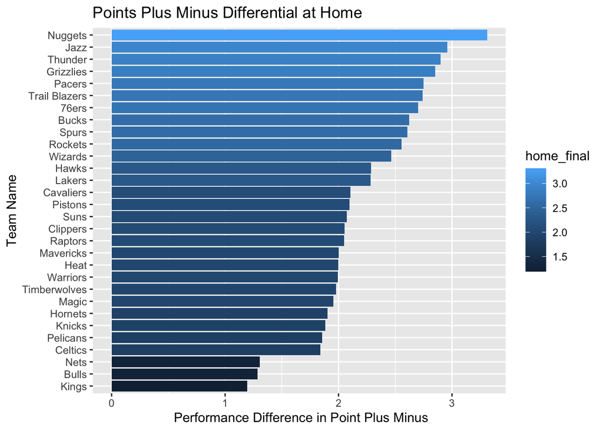

```r
avg_homediff %>%
  ggplot(aes(y = reorder(teamName,home_final),
             x = home_final,
             fill = home_final)) + geom_col() +   labs(
    title = "Points Plus Minus Differential at Home",
    x = " Performance Difference in Point Plus Minus",
    y = "Team Name"
  )
```

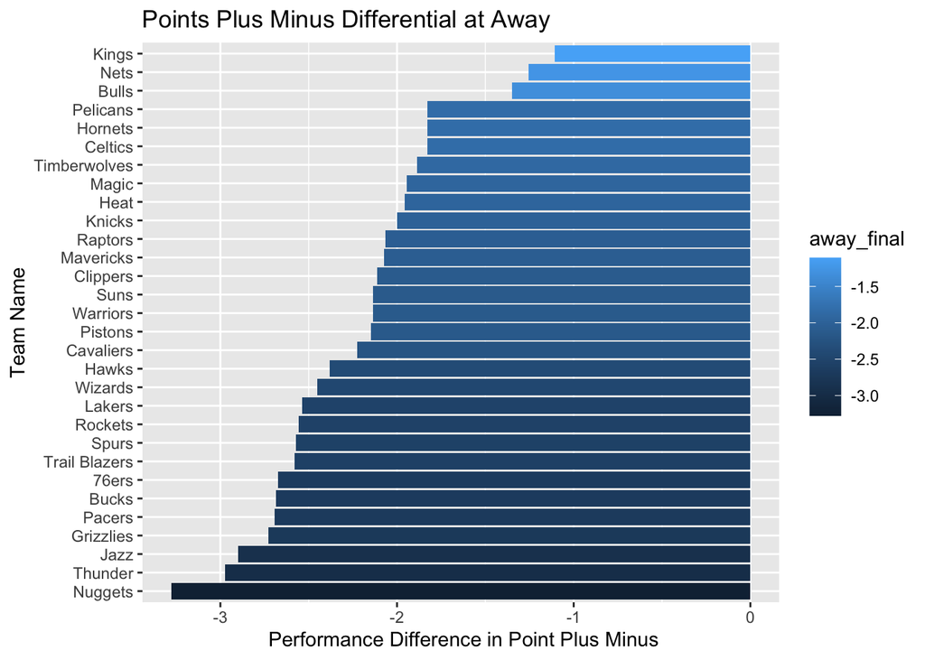

```r
avg_awaydiff %>%
  ggplot(aes(y = reorder(teamName,away_final),
             x = away_final,
             fill = away_final)) + geom_col() +labs(
    title = "Points Plus Minus Differential at Away",
    x = " Performance Difference in Point Plus Minus",
    y = "Team Name"
  )
```

# **Travel Distance Section**

## Load initial data

This is a table with a row for each game per team. So two rows per game, one for the home and away team.

```r
library(tidyverse)
Team_Data <- read_csv("data/TeamStatistics.csv")
```

## Filter data to certain date

Also we only want the rows from the perspective of away teams.

```r
Team_Data <- Team_Data %>%
  filter(year(gameDate)>=2015,home == 0)
```

## disambiguate city names

Lakers and Clipper both play in LA

```r
travelingCities <- Team_Data %>%
  pull(teamCity)
travelingNames <- Team_Data %>%
  pull(teamName)
oppCities <- Team_Data %>%
  pull(opponentTeamCity)
oppNames <- Team_Data %>%
  pull(opponentTeamName)

cleanCities <- function(cities, names){
  for(i in 1:length(cities)){
    city <- cities[i]
    if(city %in% c("LA", "Los Angeles")){
      if(names[i] == "Lakers"){
        city <- "LA_LAK"
      }else if(names[i] == "Clippers"){
        city <- "LA_CLI"
      }
    }
    cities[i] = city
  }
  return (cities)
}

Team_Data$teamCity <- cleanCities(travelingCities, travelingNames)
Team_Data$opponentTeamCity <- cleanCities(oppCities, oppNames)

rm(travelingCities, travelingNames, oppCities, oppNames, cleanCities)
```

## generate distances

Using the Lookup table to add a column travelDist, which is the estimated travel distance, calculated as the distance between the home team and the away team.

The details of generating the dist Lookup are abstracted in this report because we believe that that solving that problem was a math question, not a data science one. However, details can be found in the genLocations.R file. For our purposes, assume that distLookup
$$city1, city2$$
is the distance between the two cities.

```r
readLookup <- read.csv("./generatedData/distLookup.csv", row.names = 1)

travelDists <- 1:nrow(Team_Data)
travelingCities <- Team_Data %>% pull(teamCity)
oppCities <- Team_Data %>% pull(opponentTeamCity)

travelingCities <- gsub(" ", "_", travelingCities)
oppCities <- gsub(" ", "_", oppCities)

for(i in 1:length(travelDists)){
  dist <- readLookup[travelingCities[i],oppCities[i]]
  if(!is.numeric(dist)){
    #print(playerCity)
    #print(oppCity)
    dist <- 0
  }
  travelDists[i] <- dist
}

readLookup[travelingCities[1],oppCities[1]]
```

```
## [1] 362.1026
```

```r
Team_Data$travelDist <- travelDists


Team_Data %>%
  relocate(teamCity, opponentTeamCity, travelDist, .before=1)
```

```
## # A tibble: 14,625 × 49
##    teamCity      opponentTeamCity travelDist gameId gameDate            teamName
##    <chr>         <chr>                 <dbl>  <dbl> <dttm>              <chr>
##  1 Phoenix       LA_CLI                 362. 2.25e7 2025-11-08 22:30:00 Suns
##  2 Indiana       Denver                1000. 2.25e7 2025-11-08 21:00:00 Pacers
##  3 New Orleans   San Antonio            503. 2.25e7 2025-11-08 20:00:00 Pelicans
##  4 Chicago       Cleveland              771. 2.25e7 2025-11-08 20:00:00 Bulls
##  5 LA_LAK        Atlanta               1934. 2.25e7 2025-11-08 20:00:00 Lakers
##  6 Portland      Miami                 2704. 2.25e7 2025-11-08 20:00:00 Trail B…
##  7 Toronto       Philadelphia           337. 2.25e7 2025-11-08 19:30:00 Raptors
##  8 Dallas        Washington            1183. 2.25e7 2025-11-08 19:00:00 Maveric…
##  9 Golden State  Denver                 945. 2.25e7 2025-11-07 22:00:00 Warriors
## 10 Oklahoma City Sacramento            1337. 2.25e7 2025-11-07 22:00:00 Thunder
## # ℹ 14,615 more rows
## # ℹ 43 more variables: teamId <dbl>, opponentTeamName <chr>,
## #   opponentTeamId <dbl>, home <dbl>, win <dbl>, teamScore <dbl>,
## #   opponentScore <dbl>, assists <dbl>, blocks <dbl>, steals <dbl>,
## #   fieldGoalsAttempted <dbl>, fieldGoalsMade <dbl>,
## #   fieldGoalsPercentage <dbl>, threePointersAttempted <dbl>,
## #   threePointersMade <dbl>, threePointersPercentage <dbl>, …
```

```r
Team_Data <- Team_Data %>%
  relocate(teamCity, opponentTeamCity, travelDist, .before=1) %>%
  filter(travelDist != 0)
```

## graphing and testing win rate over travel dist

There seems to be no correlation. See conclusion for more details as to why on we believe we arrived at this surprising conclusion

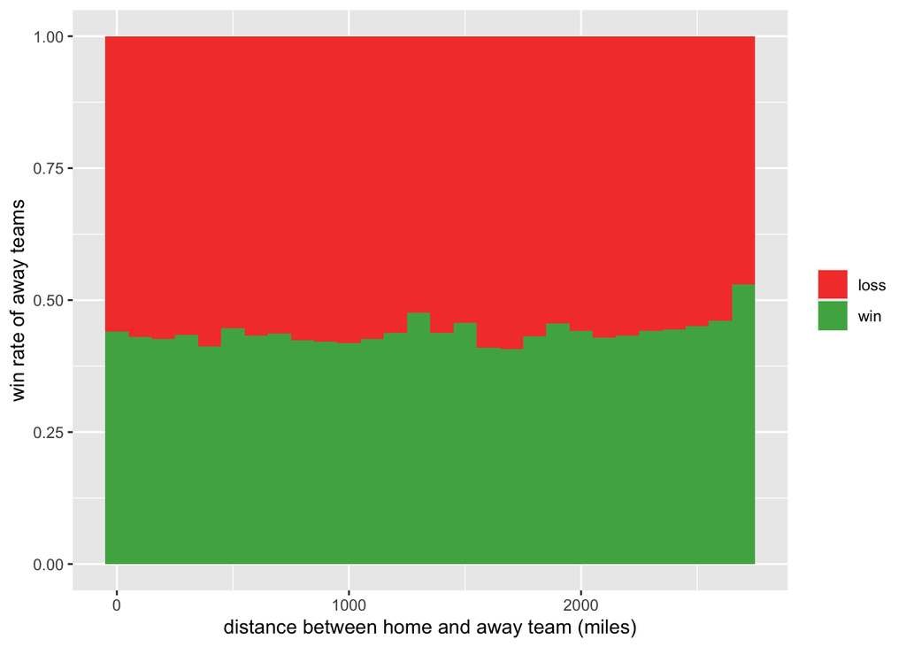

```r
Team_Data <- Team_Data
Team_Data %>%
  ggplot(aes(x = travelDist,
             fill = if_else(win==1, "win", "loss"),
            )
         ) +
  geom_histogram(binwidth = 100, position = "fill") +
  scale_fill_manual(values = c("loss" = "#F44336", "win" = "#4CAF50")) +
  labs(
    x = "distance between home and away team (miles)",
    y = "win rate of away teams",
  ) +
  theme(
    legend.title = element_blank()
  )
```

```r
cor.test(Team_Data$travelDist, Team_Data$win)
```

```
##
##  Pearson's product-moment correlation
##
## data:  Team_Data$travelDist and Team_Data$win
## t = 1.2599, df = 14617, p-value = 0.2077
## alternative hypothesis: true correlation is not equal to 0
## 95 percent confidence interval:
##  -0.005790922  0.026626512
## sample estimates:
##        cor
## 0.01042053
```

# **Franchise Effect**

## Load initial data

This is the primary data set and includes Box Scores for each player in each game

```r
library(tidyverse)
players <- read_csv("./data/PlayerStatistics.csv")
```

## Find how many teams don’t exist anymore

```r
players %>%
  filter(year(gameDate) > 1970) %>%
  distinct(playerteamCity) %>%
  anti_join(
    players %>%
      filter(year(gameDate) == 2024) %>%
      distinct(playerteamCity),
    by = "playerteamCity"
  )
```

```
## # A tibble: 16 × 1
##    playerteamCity
##    <chr>
##  1 LA
##  2 Guangzhou
##  3 South East Melbourne
##  4 Hapoel
##  5 Melbourne
##  6 New Jersey
##  7 Seattle
##  8 Vancouver
##  9 Kansas City
## 10 San Diego
## 11 Buffalo
## 12 Kansas City-Omaha
## 13 Capital
## 14 Baltimore
## 15 Cincinnati
## 16 San Francisco
```

## Clean Box Scores

Filter data to certain date (2015) and remove international teams

```r
players <- players %>%
  filter(year(gameDate)>=2015,
         gameType %in% c("Playoffs", "Regular Season", "Play-in Tournament", NA),
         numMinutes>0,
         !playerteamName %in% c("United", "Loong-Lions", "Jerusalem B.C.", "Pheonix"))
```

## Load Secondary dataset

each row in this dataset is a unique game/team used for calculating win rates and thats it

```r
library(lubridate)
Team_Data <- read_csv("data/TeamStatistics.csv")
Team_Data <- Team_Data %>%
  select( gameDate, teamName, teamId, opponentTeamName, opponentTeamId, gameId, home, win, teamScore, assists, teamCity, steals, fieldGoalsAttempted, fieldGoalsMade, fieldGoalsPercentage, threePointersPercentage, freeThrowsPercentage, reboundsTotal, pointsFastBreak, pointsFromTurnovers, pointsSecondChance, pointsInThePaint) %>%
  # clean data
  # There were some international teams that were removed
  #filter(!(teamId %in% c(15016,15018, 50013, 50014))) %>%
  filter(year(gameDate) >= 2015)

Team_Data %>% distinct(teamName)
```

```
## # A tibble: 34 × 1
##    teamName
##    <chr>
##  1 Clippers
##  2 Suns
##  3 Nuggets
##  4 Pacers
##  5 Hawks
##  6 Cavaliers
##  7 Pelicans
##  8 Bulls
##  9 Lakers
## 10 Heat
## # ℹ 24 more rows
```

## Calculate win rate

Basically, its pretty hard to quantifiable say what contributes to a team culture and measure it quantitatively. One of the ways this can be measured is through win rate.

```r
#Calculating win rate for every team

win_rate_data <- Team_Data %>%
  group_by(teamName) %>%
  summarise(total_wins = sum(win), total_games = n()) %>%
  mutate(winRate= total_wins / total_games)

win_rate_data %>%
  select(teamName, winRate) %>%
  arrange(desc(winRate))
```

```
## # A tibble: 34 × 2
##    teamName  winRate
##    <chr>       <dbl>
##  1 Warriors    0.645
##  2 Celtics     0.633
##  3 Bucks       0.585
##  4 Clippers    0.579
##  5 Nuggets     0.574
##  6 Thunder     0.571
##  7 Raptors     0.556
##  8 Cavaliers   0.539
##  9 Heat        0.538
## 10 Rockets     0.529
## # ℹ 24 more rows
```

In order to visualize the win rate and which teams are good and bad we created a column diagram with ggplot. The graph was flipped on its side and a line at 0.5 win rate was introduced, to show the cut of for a good/bad team. Teams with a win rate over 50% was given a green color and teams with a win rate below 50% was given a red color.

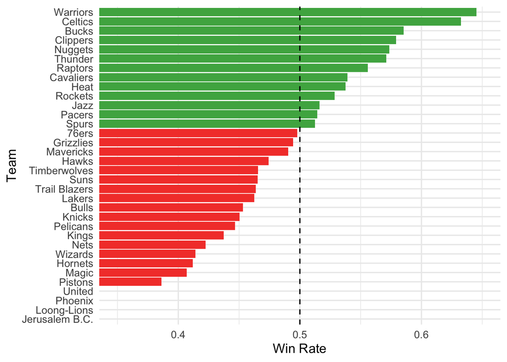

```r
win_rate_data %>%
  mutate(color_group = ifelse(winRate < 0.5, "red", "green")) %>%
  ggplot(aes(x = reorder(teamName, winRate),
             y = winRate,
             fill = color_group)) +
  geom_col() +
  geom_hline(yintercept = 0.5, linetype = "dashed")+      # line at 0.5
  coord_flip(ylim = c(0.35, 0.65)) +                      # zoomed graph around line at 0.5
  scale_fill_manual(values = c("red" = "#F44336",
                               "green" = "#4CAF50"))+    # assinging color
  theme_minimal(base_size = 13) +
  guides(fill = "none") +
  labs(y = "Win Rate", x = "Team")
```

## Bulk Calculation

career caluclates each players average standard deviations for their major stats zScores for each game and given their career mean and standard dev. then by team, calculates each players average z score for each stat on that team in their career

Positive values are better than average performances and negative are worse than average

```r
career <- players %>%
  group_by(personId) %>%
  mutate(PPM = points/numMinutes) %>%
  summarize(careerPPM = mean(PPM),
            careerPPG = mean(points),
            careerGames = n(),
            careerMinutes = sum(numMinutes),
            sdPoints = sd(points),
            sdPPM = sd(PPM),
            careerFAPG = mean(fieldGoalsAttempted),
            sdFAPG = sd(fieldGoalsAttempted),
            careerFGP = mean(fieldGoalsPercentage),
            sdFGP = sd(fieldGoalsPercentage)) %>%
  filter(!is.na(sdPoints))

zPlayers <- players %>%
  inner_join(career, by = join_by(personId == personId)) %>%
  mutate(PPM = points/numMinutes,
         zPPG = (points-careerPPG)/sdPoints,
         zPPM = (PPM-careerPPM)/sdPPM,
         zFAPG = (fieldGoalsAttempted-careerFAPG)/sdFAPG,
         zFGP = (fieldGoalsPercentage-careerFGP)/sdFGP)

byTeam <- zPlayers %>%
  filter(numMinutes>0) %>%
  mutate(year = year(gameDate)) %>%
  group_by(personId, playerteamName, year) %>%
  mutate(PPM = points/numMinutes) %>%
  summarize(teamPPM = mean(PPM),
            teamPPG = mean(points),
            teamGames = n(),
            teamMinutes = sum(numMinutes),
            zAvgPPG = mean(zPPG),
            zAvgPPM = mean(zPPM),
            zAvgFAPG = mean(zFAPG),
            zAvgFGP = mean(zFGP))
#names <- players %>% select(firstName, lastName, personId)

#names %>% filter(lastName == "Westbrook")

# not sure why I can't do the below instead of the above filter. Somehow this causes byTeam to ungroup

  # left_join(names, by = "personId") %>%
  # relocate(firstName, lastName, zAvgPPG, zAvgPPM,playerteamName, .before = 1) %>%
  # filter(firstName == "LeBron")

#There are a couple of people for whom have played<3 games and scored <2 points that cause avgZssoc to be NA
#See below code chunk
```

So for example, players who played on one team their whole career would have a zAvgPPG and zAvgPPM of 0. However, if a player played for the Lakers and Cavaliers but had higher PPG stats on the cavaliers then the their entries would look like the following:

```r
#LeBron
byTeam %>%
  filter(personId == 2544) %>%
  select(playerteamName, year, zAvgPPG)
```

```
## # A tibble: 12 × 4
## # Groups:   personId, playerteamName [2]
##    personId playerteamName  year zAvgPPG
##       <dbl> <chr>          <dbl>   <dbl>
##  1     2544 Cavaliers       2015 -0.0493
##  2     2544 Cavaliers       2016 -0.186
##  3     2544 Cavaliers       2017  0.199
##  4     2544 Cavaliers       2018  0.344
##  5     2544 Lakers          2018  0.0607
##  6     2544 Lakers          2019 -0.107
##  7     2544 Lakers          2020 -0.104
##  8     2544 Lakers          2021 -0.0903
##  9     2544 Lakers          2022  0.448
## 10     2544 Lakers          2023 -0.0224
## 11     2544 Lakers          2024 -0.249
## 12     2544 Lakers          2025 -0.232
```

## Calculate Team Association indexes by year Now, we average the zAvgPPG for each player who played for said team since 2015, weighted by the minutes a player played for that team. We weight it because the results starter who player >70 games a season matter more than a bench player who played in <10 games a season.

```r
teamAssoc <- byTeam %>%
  group_by(playerteamName, year) %>%
  summarize(avgAssocPPG = mean(zAvgPPG*teamMinutes, na.rm = TRUE),
            avgAssocPPM = mean(zAvgPPM*teamMinutes, na.rm = TRUE),
            avgAssocFAPG = mean(zAvgFAPG*teamMinutes, na.rm = TRUE),
            avgAssocFGP = mean(zAvgFGP*teamMinutes, na.rm = TRUE)) %>%
  arrange(desc(avgAssocPPG))
teamAssoc %>% arrange()
```

```
## # A tibble: 330 × 6
## # Groups:   playerteamName [30]
##    playerteamName  year avgAssocPPG avgAssocPPM avgAssocFAPG avgAssocFGP
##    <chr>          <dbl>       <dbl>       <dbl>        <dbl>       <dbl>
##  1 Pacers          2015        333.       125.          454.       28.0
##  2 Pacers          2021        322.       115.          392.       42.0
##  3 Heat            2017        308.       116.          347.       91.5
##  4 Knicks          2024        292.       139.          329.       37.9
##  5 Pistons         2015        281.        76.6         414.        3.75
##  6 Thunder         2025        249.       178.          275.       27.6
##  7 Kings           2015        249.        28.4         301.       35.1
##  8 Mavericks       2016        246.        44.8         348.      -14.6
##  9 Trail Blazers   2022        233.        58.4         239.       73.9
## 10 Rockets         2015        231.       104.          286.       30.2
## # ℹ 320 more rows
```

## Finding data for total teams & corelation between indexes

We explored if any of the indexes seem to have a correlation between each other. They do. attempts, PPG and PPM all have a positive correlation. But FGP does not

```r
totalTeamAssoc <- teamAssoc %>%
  group_by(playerteamName) %>%
  select(-year) %>%
  summarize_all(mean) %>%
  left_join(win_rate_data, join_by(playerteamName == teamName))
totalTeamAssoc
```

```
## # A tibble: 30 × 8
##    playerteamName avgAssocPPG avgAssocPPM avgAssocFAPG avgAssocFGP total_wins
##    <chr>                <dbl>       <dbl>        <dbl>       <dbl>      <dbl>
##  1 76ers                55.2        -6.05        78.1         2.81        489
##  2 Bucks               -31.5       -49.7        -45.1        14.8         590
##  3 Bulls                83.0        18.8        112.          3.93        425
##  4 Cavaliers            41.4        -6.86        38.4        20.0         545
##  5 Celtics               8.70       -4.67        -6.08       15.4         675
##  6 Clippers             32.3        12.9         25.7        38.7         574
##  7 Grizzlies            89.9        43.2        114.          9.12        481
##  8 Hawks                89.0        43.7        113.         29.2         463
##  9 Heat                 65.5        15.5         71.3        24.4         551
## 10 Hornets             115.         53.7        139.         29.6         377
## # ℹ 20 more rows
## # ℹ 2 more variables: total_games <int>, winRate <dbl>
```

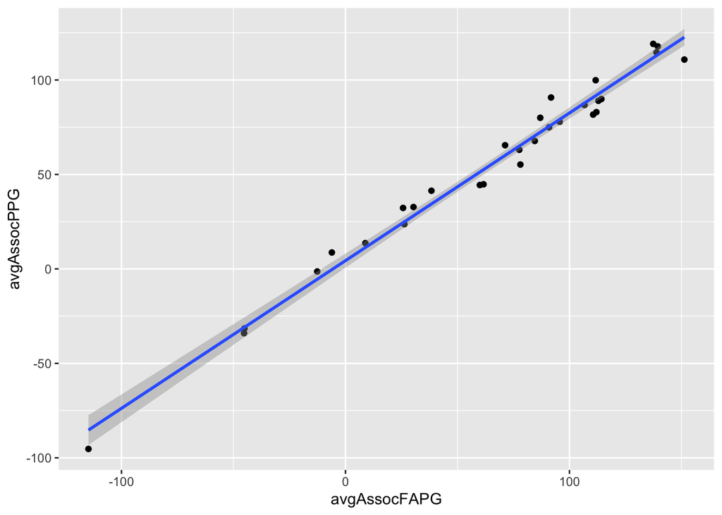

```r
totalTeamAssoc %>%
  ggplot(aes(x = avgAssocFAPG, y = avgAssocPPG)) +
  geom_point() +
  geom_smooth(method = "lm")
```

```r
print("correlation between attempts and PPG")
```

```
## [1] "correlation between attempts and PPG"
```

```r
cor.test(totalTeamAssoc$avgAssocFAPG, totalTeamAssoc$avgAssocPPG)
```

```
##
##  Pearson's product-moment correlation
##
## data:  totalTeamAssoc$avgAssocFAPG and totalTeamAssoc$avgAssocPPG
## t = 38.37, df = 28, p-value < 2.2e-16
## alternative hypothesis: true correlation is not equal to 0
## 95 percent confidence interval:
##  0.9801690 0.9955797
## sample estimates:
##       cor
## 0.9906243
```

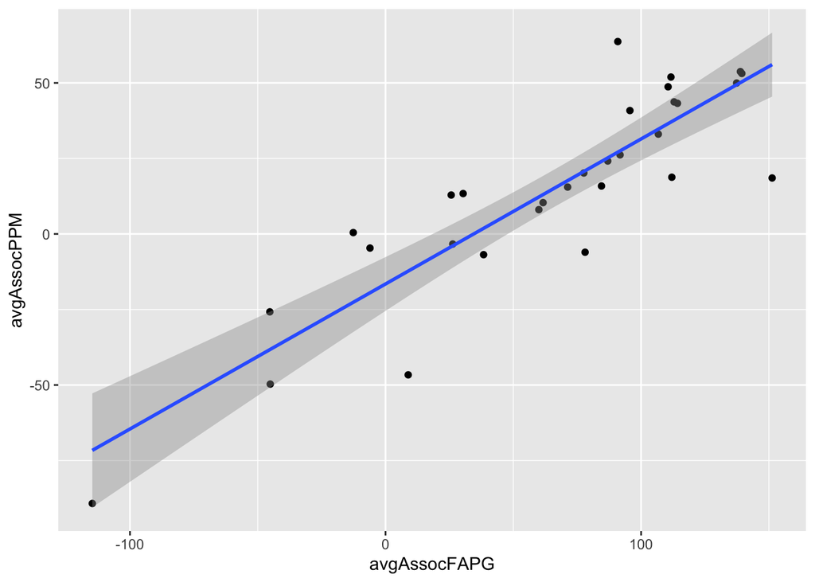

```r
totalTeamAssoc %>%
  ggplot(aes(x = avgAssocFAPG, y = avgAssocPPM)) +
  geom_point() +
  geom_smooth(method = "lm")
```

```r
print("correlation between attempts and PPM")
```

```
## [1] "correlation between attempts and PPM"
```

```r
cor.test(totalTeamAssoc$avgAssocFAPG, totalTeamAssoc$avgAssocPPM)
```

```
##
##  Pearson's product-moment correlation
##
## data:  totalTeamAssoc$avgAssocFAPG and totalTeamAssoc$avgAssocPPM
## t = 9.8981, df = 28, p-value = 1.206e-10
## alternative hypothesis: true correlation is not equal to 0
## 95 percent confidence interval:
##  0.7645225 0.9426592
## sample estimates:
##       cor
## 0.8818895
```

```r
print("correlation between attempts and FGP")
```

```
## [1] "correlation between attempts and FGP"
```

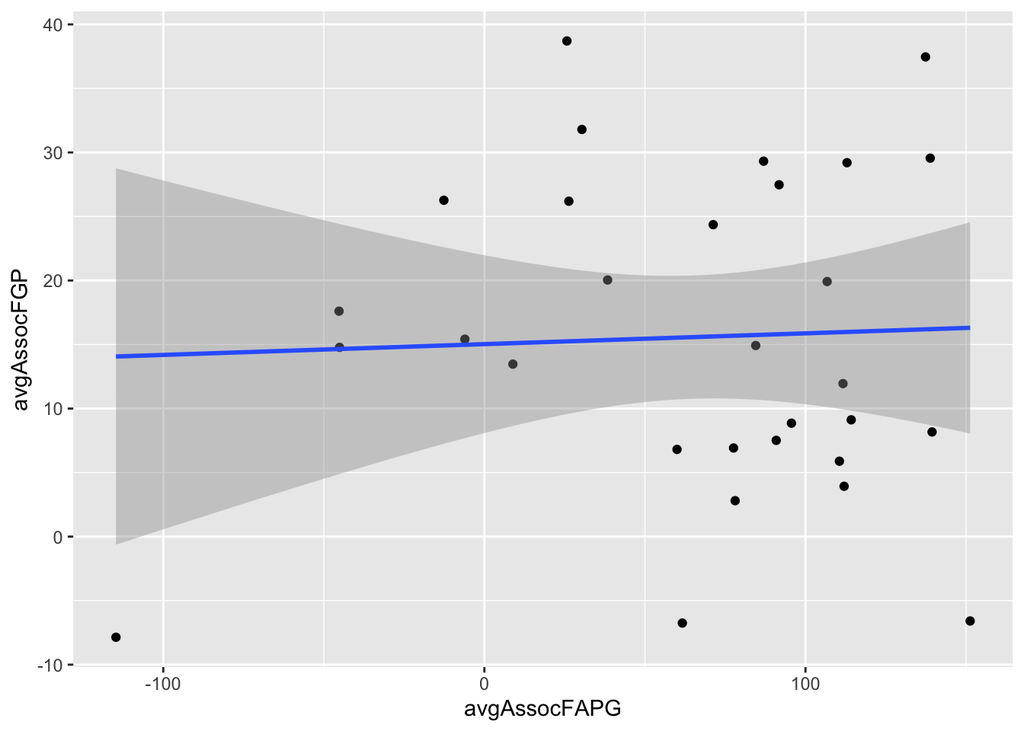

```r
totalTeamAssoc %>%
  ggplot(aes(x = avgAssocFAPG, y = avgAssocFGP)) +
  geom_point() +
  geom_smooth(method = "lm")
```

```r
cor.test(totalTeamAssoc$avgAssocFAPG, totalTeamAssoc$avgAssocFGP)
```

```
##
##  Pearson's product-moment correlation
##
## data:  totalTeamAssoc$avgAssocFAPG and totalTeamAssoc$avgAssocFGP
## t = 0.223, df = 28, p-value = 0.8252
## alternative hypothesis: true correlation is not equal to 0
## 95 percent confidence interval:
##  -0.3230650  0.3963616
## sample estimates:
##        cor
## 0.04210478
```

## Testing win rate vs indexes

testing a correlation between win rate and the indexes of teams There seems to exist a probable correlation

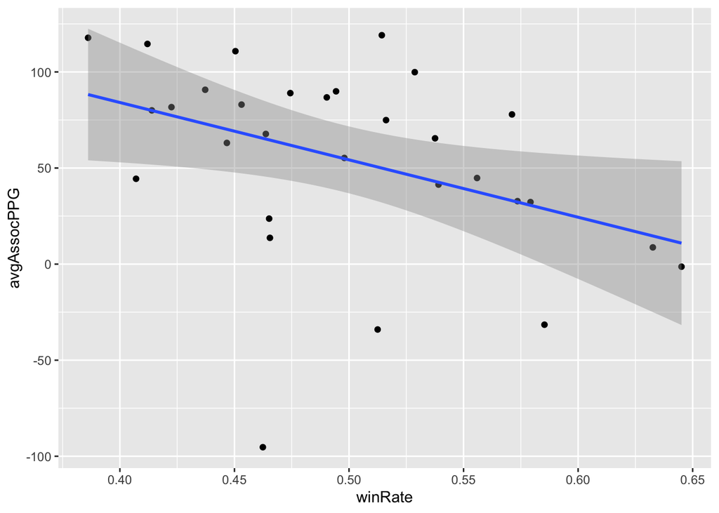

```r
totalTeamAssoc %>%
  ggplot(aes(x = winRate, y = avgAssocPPG)) +
  geom_point() + geom_smooth(method = "lm")
```

```r
cor.test(totalTeamAssoc$winRate, totalTeamAssoc$avgAssocPPG)
```

```
##
##  Pearson's product-moment correlation
##
## data:  totalTeamAssoc$winRate and totalTeamAssoc$avgAssocPPG
## t = -2.3151, df = 28, p-value = 0.02815
## alternative hypothesis: true correlation is not equal to 0
## 95 percent confidence interval:
##  -0.66506240 -0.04741076
## sample estimates:
##        cor
## -0.4008335
```

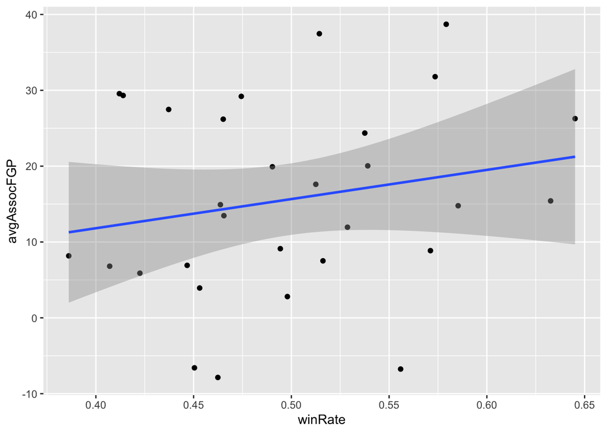

```r
totalTeamAssoc %>%
  ggplot(aes(x = winRate, y = avgAssocFGP)) +
  geom_point() +
  geom_smooth(method = "lm")
```

```r
cor.test(totalTeamAssoc$winRate, totalTeamAssoc$avgAssocPPG)
```

```
##
##  Pearson's product-moment correlation
##
## data:  totalTeamAssoc$winRate and totalTeamAssoc$avgAssocPPG
## t = -2.3151, df = 28, p-value = 0.02815
## alternative hypothesis: true correlation is not equal to 0
## 95 percent confidence interval:
##  -0.66506240 -0.04741076
## sample estimates:
##        cor
## -0.4008335
```

## Testing the indexes in ANOVA

anova testing only shows signifcance of a relationship between PPG and teams This partially contradicts correlation testing

```r
teamAssocB <- teamAssoc %>%
  left_join(win_rate_data, join_by(playerteamName == teamName))

modelPPG <- aov(avgAssocPPG ~ playerteamName, data = teamAssocB)
summary(modelPPG)
```

```
##                 Df  Sum Sq Mean Sq F value   Pr(>F)
## playerteamName  29  794178   27385   3.168 3.36e-07 ***
## Residuals      300 2593703    8646
## ---
## Signif. codes:  0 '***' 0.001 '**' 0.01 '*' 0.05 '.' 0.1 ' ' 1
```

```r
modelFGP <- aov(avgAssocFGP ~ playerteamName, data = teamAssocB)
summary(modelFGP)
```

```
##                 Df Sum Sq Mean Sq F value Pr(>F)
## playerteamName  29  51088    1762   1.071  0.371
## Residuals      300 493267    1644
```

## Graphing the indexes for last 10 years by team

summarize the major index values: PPG and FGP FGAP and PPM correlate already with PPG so not graphed

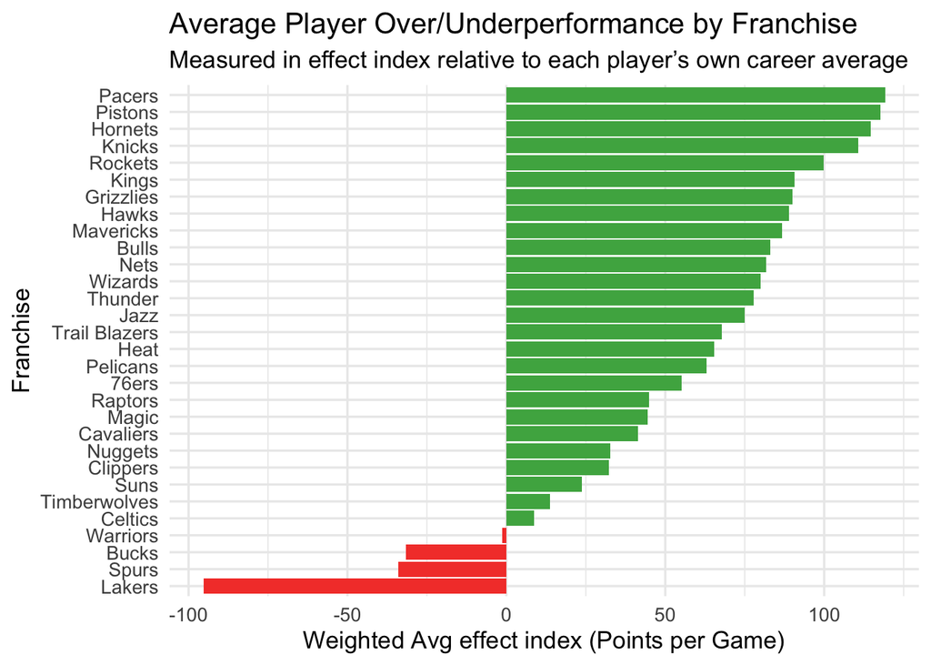

```r
library(ggthemes)

totalTeamAssoc %>%
  ggplot(aes(x = reorder(playerteamName, avgAssocPPG),
             y = avgAssocPPG,
             fill = avgAssocPPG > 0)) +
  geom_col(show.legend = FALSE) +
  coord_flip() +
  labs(title = "Average Player Over/Underperformance by Franchise",
       subtitle = "Measured in effect index relative to each player’s own career average",
       x = "Franchise",
       y = "Weighted Avg effect index (Points per Game)") +
  scale_fill_manual(values = c("TRUE" = "#4CAF50", "FALSE" = "#F44336")) +
  theme_minimal(base_size = 13)
```

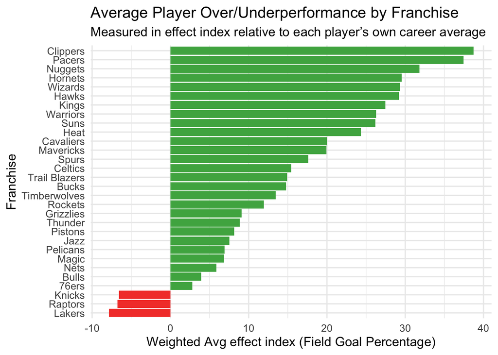

```r
totalTeamAssoc %>%
  ggplot(aes(x = reorder(playerteamName, avgAssocFGP),
             y = avgAssocFGP,
             fill = avgAssocFGP > 0)) +
  geom_col(show.legend = FALSE) +
  coord_flip() +
  labs(title = "Average Player Over/Underperformance by Franchise",
       subtitle = "Measured in effect index relative to each player’s own career average",
       x = "Franchise",
       y = "Weighted Avg effect index (Field Goal Percentage)") +
  scale_fill_manual(values = c("TRUE" = "#4CAF50", "FALSE" = "#F44336")) +
  theme_minimal(base_size = 13)
```

## What do indexes mean?

So far the indexes have been abstract. Here is a sample table that shows how much of an effect our indexes mean. Its very small. We estimate that the strongest effect is ~2 extra PPG or ~2% more FG%

```r
yearTested <- 2025

mins <- byTeam %>%
  filter(year == yearTested) %>%
  group_by(playerteamName) %>%
  summarize(avgTeamMinutes = mean(teamMinutes))

weightedSds <- career %>%
  filter(careerMinutes!=0) %>%
  summarize(centralSdFgp = mean(sdFGP*careerMinutes),
            meanCareerMinutes = mean(careerMinutes),
            centralSdPpg = mean(sdPoints*careerMinutes)) %>%
  mutate(SdFgp = centralSdFgp/meanCareerMinutes,
         SdPpg = centralSdPpg/meanCareerMinutes)

left_join(totalTeamAssoc, mins, by = "playerteamName") %>%
  mutate(FgpEffect = avgAssocFGP*weightedSds$SdFgp/avgTeamMinutes*100,
         PpgEffect = avgAssocPPG*weightedSds$SdPpg/avgTeamMinutes) %>%
  arrange(desc(PpgEffect)) %>%
  relocate(PpgEffect, FgpEffect, avgAssocPPG, avgAssocFGP, .after = 1)
```

```
## # A tibble: 30 × 11
##    playerteamName PpgEffect FgpEffect avgAssocPPG avgAssocFGP avgAssocPPM
##    <chr>              <dbl>     <dbl>       <dbl>       <dbl>       <dbl>
##  1 Hornets             1.88     1.55        115.        29.6         53.7
##  2 Kings               1.41     1.36         90.7       27.5         26.2
##  3 Pistons             1.27     0.281       118.         8.17        53.1
##  4 Grizzlies           1.21     0.392        89.9        9.12        43.2
##  5 Mavericks           1.18     0.869        86.8       19.9         33.0
##  6 Pacers              1.18     1.19        119.        37.5         50.0
##  7 Wizards             1.16     1.36         80.0       29.3         24.1
##  8 Hawks               1.15     1.20         89.0       29.2         43.7
##  9 Knicks              1.14    -0.217       111.        -6.59        18.5
## 10 Nets                1.05     0.243        81.7        5.89        48.7
## # ℹ 20 more rows
## # ℹ 5 more variables: avgAssocFAPG <dbl>, total_wins <dbl>, total_games <int>,
## #   winRate <dbl>, avgTeamMinutes <dbl>
```

```r
rm(mins,weightedSds)
```

# **Improvements**

If we were tasked with doing this project again, instead of using a different year for each observation we could separate each observation by a unique season. Also for the travel distance calculations, we could have calculated a teams travel distance from the city they last played at instead of calculating from their home city to their next game. This will give us a better idea of how much a team traveled because teams don’t usually fly back home after each game. Instead they fly directly towards the city where their next game is going to be played.

Another area that would help improve the quality of our project is the sheer amount of data available to us. We chose to focus on only the last 10 years of games since this is what is considered the “modern era” of the NBA. This era is identified through the high number of three point shots and layups taken and the phasing out of the mid range shot. Filtering our data like this only gave us the last 10 years of players being transferred from one team to another. Including more instances while also keeping the era/playstyle the same would definitely improve the accuracy of our results.

# **Conclusion**

## **Home court Advantage**

The rest of the teams measured seemed to have a generally the same average increase in how they played at home vs their average. All the rest of the teams had around a range from 1.8-2.8 increase in their average plus minus. However, there were three other teams that stuck out on the lower end. These teams were the Bulls, Nets, and the Kings. 3 franchises known for not having strong fan bases and relative central positions compared to other teams. This allows fans from other franchises to essentially take over their home games and take away from their home court advantage.

## **Travel distance**

In our research we performed a distance calculation for the distance between two teams’ home stadiums and after analysing the result we could only find a weak correlation between a longer travel distance and win rate. The hypothesis was that the longer a team has to travel for a game the more likely it is that they are going to perform poorly. This does not seem to be the case for our study. We can see in our data and in our t-test that there seems to be no significant correlation between travel distance and win rate. This leads one to believe that travel might not be a big factor in the NBA.

However, in other studies such as Charest J, et. al. Impacts of travel distance and travel direction on back-to-back games in the National Basketball Association. J Clin Sleep Med. 2021 Nov 1 (17 (11):2269-2274. doi: 10.5664/jcsm.9446) they come to a different conclusion. Their findings support the idea that travel fatigue and or circadian disruption influences performance making travel distance a legitimate factor. However, to what degree it affects the team’s performance is uncertain. This is due to the interplay of many factors. Factors like jet lag, circadian disruption, rest days, schedule density (back-to-backs), crowd presence, team quality all interact in complex ways and combined with the actual travel distance.

In our study we assumed that a team travels from their home arena to their opponents arena for that game, plates the game and then returns to their own home arena. This might not be a perfect representation of reality because games might be scheduled so that a team plays a series of away games in a sequence to reduce the travel distance in between each game. In addition, the means of travel a team uses can be different if they go by bus the travel time will probably be longer than if they go by plane.